# Lecture 17 Unsupervised Learning II: Dimensionality Reduction

```python
import numpy as np
import matplotlib.pyplot as plt

%matplotlib inline
```

## PCA

Let's create a synthetic dataset to understand SVD. The dataset looks like the following.

```python
# Generate some isotropic data
Z = np.random.normal(0, 1, [100, 2])

L = np.array([[1,2], [3,4]])

# Generate data
X = np.dot(Z, L.T)
```

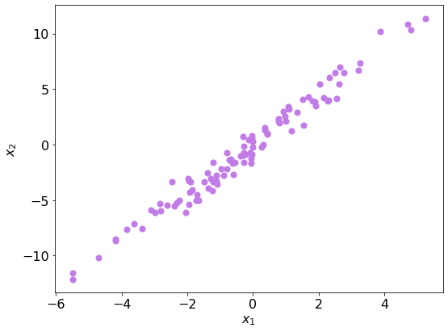

```python
# Visualize the generated data
plt.figure(figsize=(8, 6))
plt.rcParams.update({"font.size": 16})
plt.scatter(X[:, 0], X[:, 1], s=50, c="#C27CE8")
plt.xlabel('$x_1$')
plt.ylabel('$x_2$')
plt.tight_layout()
plt.show()
```

We can notice that the data is distributed in two dimensions.

`Step 1`: Normalize the data by subtracting the respective means from the numbers in the respective column.

```
Means of X:  [-0.27525325 -0.59676981]
```

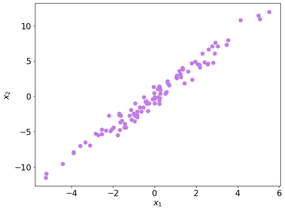

```python
normalized_X = X - np.mean(X, axis=0)

print("Means of X: ", np.mean(X, axis=0))

# Visualize the normalized data
plt.figure(figsize=(8, 6))
plt.rcParams.update({"font.size": 16})
plt.scatter(normalized_X[:, 0], normalized_X[:, 1], s=50, c="#C27CE8")
plt.xlabel('$x_1$')
plt.ylabel('$x_2$')
plt.tight_layout()
plt.show()
```

`Step 2`: Calculate the covariance matrix to understand their correlation.

```python
C = normalized_X.T @ normalized_X
```

`Step 3`: Calculate the eigenvalues and eigenvectors of the covariance matrix.

```python
Lambda_eig, U_eig = np.linalg.eigh(C)

print(Lambda_eig)
```

```
[  11.07189218 2736.53982089]
```

The eigenvalues reflect the importance of different axes of the dataset. The importance of different axes is directly proportional to the eigenvalues.

Here, the second eigenvalue is significantly higher than the other.

`Step 4`: Choose 𝒌 feature vectors (eigenvectors) based on the largest 𝒌 eigenvalues.

```python
# Normalize columns of U_eig
U_eig = U_eig / np.linalg.norm(U_eig, axis=1)

# Select the second eigenvector as the feature vector
u2 = U_eig[:, 1].reshape(-1, 1)
```

Step 5: Form principal components.

```python
# Project
U2 = X @ u2

# For visualization
u1 = U_eig[:, 0].reshape(-1, 1)
U1 = X @ u1
```

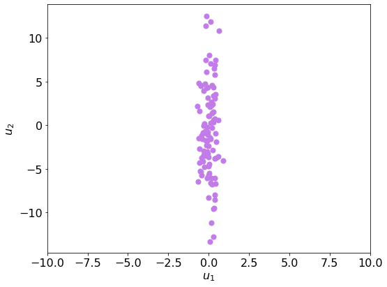

```python
# Visualize the normalized data
plt.figure(figsize=(8, 6))
plt.rcParams.update({"font.size": 16})
plt.scatter(U1, U2, s=50, c="#C27CE8")
plt.xlabel('$u_1$')
plt.ylabel('$u_2$')
plt.xlim(-10, 10)
plt.tight_layout()
plt.show()
```

The second eigenvalue is higher than the first. Thus the second axis is more important than the first axis.

So, after projecting the data on to the principal axes, we can see that the second principal axis captures the more variability than the first principal axis.

In other words, the variation of the data captured by the second principal axis is significantly more than that by the first principal axis.

## PCA with SVD

Let's deploy PCA with SVD on the same dataset.

`Step 1`: Normalize the data by subtracting the respective means from the numbers in the respective column.

And, observe how the dataset looks like.

```
Means of X:  [-0.27525325 -0.59676981]
```

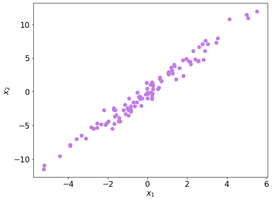

```python
normalized_X = X - np.mean(X, axis=0)

print("Means of X: ", np.mean(X, axis=0))

# Visualize the normalized data
plt.figure(figsize=(8, 6))
plt.rcParams.update({"font.size": 16})
plt.scatter(normalized_X[:, 0], normalized_X[:, 1], s=50, c="#C27CE8")
plt.xlabel('$x_1$')
plt.ylabel('$x_2$')
plt.tight_layout()
plt.show()
```

`Step 2`: Calculate the singular values and singular vectors using SVD.

$$A_{m\times n} = U_{m \times m} S_{m \times n} V^T_{n \times n}$$

The shape of the dataset A is $100 \times 2$. Thus,

| Matrix | Shape |
| --- | --- |
| U | 100 x 100 |
| S | 100 x 2 |
| V | 2 x 2 |

`S` is a rectangular matrix. As the shape of `S` is $100 \times 2$, there will be only 2 non-zero eigenvalues on the main diagonal of S. All others will be zero. Hence, the `S` is vector of length 2.

```python
from scipy.linalg import svd

U, S, Vh = svd(normalized_X)

print("Shape of U: ", U.shape)
print("Shape of S: ", S.shape)
print("Shape of Vh: ", Vh.shape)
```

```
Shape of U:  (100, 100)
Shape of S:  (2,)
Shape of Vh:  (2, 2)
```

```python
print("The singular values in decreasing order are: ", S)
```

```
The singular values in decreasing order are:  [52.31194721  3.32744529]
```

`Step 3`: Choose components according to the singular values.

The underlying idea is to pick the components with significantly higher singular values.

`NOTE`: Since the first eigenvalue is significantly higher than the second eigenvalue, only `u1` should be picked. However, we are selecting both to visualize them in a 2D plot.

```python
# Only u1 should be picked. But we choose u1 and u2 for visualization.
u1 = U[:, 0]
u2 = U[:, 1]
```

Step 4: Form principal components.

```python
np.diag(S)
```

```
array([[52.31194721,  0.        ],
       [ 0.        ,  3.32744529]])
```

Let's see how PCA transforms the dataset.

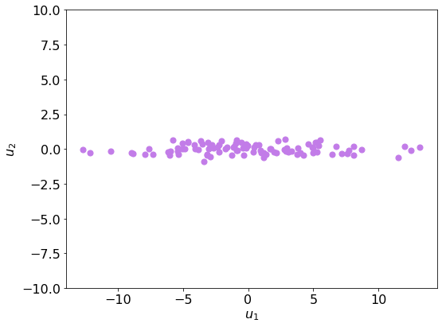

```python
# Reshape S to a m by n matrix
reshaped_S = np.zeros(shape=(U.shape[0], S.shape[0]))
reshaped_S[:S.shape[0], :] = np.diag(S)

# Project
components = U @ reshaped_S
U1 = components[:, 0]
U2 = components[:, 1]

# Visualize the normalized data
plt.figure(figsize=(8, 6))
plt.rcParams.update({"font.size": 16})
plt.scatter(U1, U2, s=50, c="#C27CE8")
plt.xlabel('$u_1$')
plt.ylabel('$u_2$')
plt.ylim(-10, 10)
plt.tight_layout()
plt.show()
```

We notice that the dominant principal component is `u1`. The data has maximum variability on the `u1` axis.

## PCA example with Iris Dataset

Let's deploy PCA on a real dataset, the `Iris dataset`.

```python
from sklearn.decomposition import PCA
from sklearn import datasets
```

Load Iris dataset.

```python
# Load Iris dataset
iris = datasets.load_iris()
X = iris.data
y = iris.target
```

Let's see the number of features of the dataset.

```python
print(f"There are {iris.data.shape[0]} points in the dataset. \nThere are {iris.data.shape[1]} features")
```

```
There are 150 points in the dataset.
There are 4 features
```

```python
pca = PCA()
pca.fit(iris.data)
```

```python
# Get ordered singular values
sigma = pca.singular_values_

print("Singular values: ", sigma)
print(f"\n\nThe information captured by the principal axes are:, \
          \n{100*sigma[0]/sum(sigma):.2f} % by the FIRST principal axis \
          \n{100*sigma[1]/sum(sigma):.2f} % by the SECOND principal axis \
          \n{100*sigma[2]/sum(sigma):.2f} % by the THIRD principal axis \
          \n{100*sigma[3]/sum(sigma):.2f} % by the FOURTH principal axis \
          ")
```

```
Singular values:  [25.09996044  6.01314738  3.41368064  1.88452351]


The information captured by the principal axes are:,
68.93 % by the FIRST principal axis
16.51 % by the SECOND principal axis
9.38 % by the THIRD principal axis
5.18 % by the FOURTH principal axis
```

Let's see the variation in the eigenvalues.

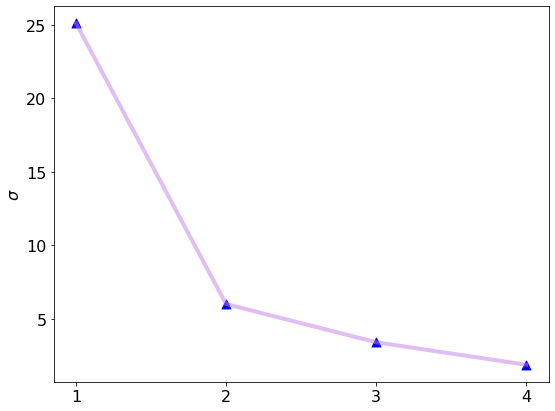

```python
indices = list(range(1, len(sigma)+1))

# Visualize singular values
plt.figure(figsize=(8, 6))
plt.rcParams.update({"font.size": 16})
plt.scatter(indices, sigma, s=80, marker="^", c="blue")
plt.plot(indices, sigma, lw=4, c="#C27CE880")
plt.ylabel('$\sigma$')
plt.xticks(indices)
plt.tight_layout()
plt.show()
```

We can see from this figure that the succeeding eigenvalues decrease in their value.

Thus, the principal components corresponding to the succeeding eigenvalues will capture lesser variation of the data.

### Visualizing two principal components

Select the first two singular vectors as the feature vectors.

```python
pca2 = PCA(n_components=2)
X_reduced2 = pca2.fit_transform(X)
```

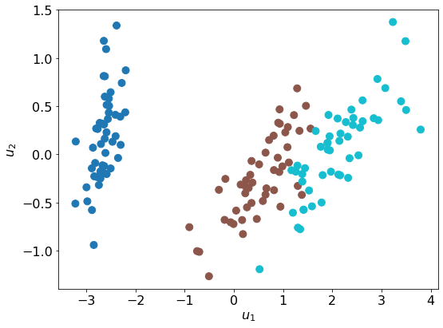

```python
# Visualize the dataset
plt.figure(figsize=(8, 6))
plt.rcParams.update({"font.size": 16})
plt.scatter(X_reduced2[:, 0], X_reduced2[:, 1], s=80, c=y, cmap="tab10")
plt.xlabel('$u_1$')
plt.ylabel('$u_2$')
plt.tight_layout()
plt.show()
```

The figure Visualilizes two principal components.

These two principal components capture $85.44 \% (= 68.93 \% + 16.51 \%) $ of information.

### Visualizing three principal components

Select the first three singular vectors as the feature vectors.

```python
pca3 = PCA(n_components=3)
X_reduced3 = pca3.fit_transform(X)

import plotly.graph_objects as go

fig = go.Figure(data=[go.Scatter3d(x=X_reduced3[:,0], y=X_reduced3[:,1], z=X_reduced3[:,2],
                                   mode='markers',
                                   marker=dict(color=y,))])

fig.update_layout(scene = dict(
                    xaxis_title='u1',
                    yaxis_title='u2',
                    zaxis_title='u3'))

fig.show()
```

[interactive chart not shown]

The figure Visualilizes THREE principal components.

These three principal components capture $94.82 \% (= 68.93 \% + 16.51 \% + 9.38 \%) $ of information.